# PEC1 Lectura y preparación de la base de datos

Nathalia Fernandez Rodrigues

22/11/2020

# 1 **Lectura y Preparación de la Base de Datos**

## 1.1 **Carga de juego de datos**

Se carga el fichero de datos **“Car_sales.csv”** del directorio de trabajo y se guardan los datos en un objeto llamado **“car”**

```r
setwd("C:/Users/natha/OneDrive/Documents")
car<- read.csv("Car_sales.csv", header=TRUE, sep=",", dec=".", fileEncoding = "UTF-8")
```

## 1.2 **Descripción de los datos**

### 1.2.1 *Descripción de la estructura de datos*

Se muestra una descripción de la estructura de datos para conocer número de filas, número de columnas, nombre de las columnas y tipo de datos:

```r
str(car)
```

```
## 'data.frame':    157 obs. of  16 variables:
##  $ Manufacturer        : chr  "Acura" "Acura" "Acura" "Acura" ...
##  $ Model               : chr  "Integra" "TL" "CL" "RL" ...
##  $ Sales_in_thousands  : num  16.92 39.38 14.11 8.59 20.4 ...
##  $ X__year_resale_value: num  16.4 19.9 18.2 29.7 22.3 ...
##  $ Vehicle_type        : chr  "Passenger" "Passenger" "Passenger" "Passenger" ...
##  $ Price_in_thousands  : num  21.5 28.4 NA 42 24 ...
##  $ Engine_size         : num  1.8 3.2 3.2 3.5 1.8 2.8 4.2 2.5 2.8 2.8 ...
##  $ Horsepower          : int  140 225 225 210 150 200 310 170 193 193 ...
##  $ Wheelbase           : num  101 108 107 115 103 ...
##  $ Width               : num  67.3 70.3 70.6 71.4 68.2 76.1 74 68.4 68.5 70.9 ...
##  $ Length              : num  172 193 192 197 178 ...
##  $ Curb_weight         : num  2.64 3.52 3.47 3.85 3 ...
##  $ Fuel_capacity       : num  13.2 17.2 17.2 18 16.4 18.5 23.7 16.6 16.6 18.5 ...
##  $ Fuel_efficiency     : int  28 25 26 22 27 22 21 26 24 25 ...
##  $ Latest_Launch       : chr  "2/2/2012" "6/3/2011" "1/4/2012" "3/10/2011" ...
##  $ Power_perf_factor   : num  58.3 91.4 NA 91.4 62.8 ...
```

### 1.2.2 *Resúmen descriptivo de la Base de datos:*

Se muestra un resúmen desctriptivo de la base de datos “car”

```r
summary(car)
```

```
##  Manufacturer          Model           Sales_in_thousands X__year_resale_value
##  Length:157         Length:157         Min.   :  0.11     Min.   : 5.16
##  Class :character   Class :character   1st Qu.: 14.11     1st Qu.:11.26
##  Mode  :character   Mode  :character   Median : 29.45     Median :14.18
##                                        Mean   : 53.00     Mean   :18.07
##                                        3rd Qu.: 67.96     3rd Qu.:19.88
##                                        Max.   :540.56     Max.   :67.55
##                                                           NA's   :36
##  Vehicle_type       Price_in_thousands  Engine_size      Horsepower
##  Length:157         Min.   : 9.235     Min.   :1.000   Min.   : 55.0
##  Class :character   1st Qu.:18.017     1st Qu.:2.300   1st Qu.:149.5
##  Mode  :character   Median :22.799     Median :3.000   Median :177.5
##                     Mean   :27.391     Mean   :3.061   Mean   :185.9
##                     3rd Qu.:31.948     3rd Qu.:3.575   3rd Qu.:215.0
##                     Max.   :85.500     Max.   :8.000   Max.   :450.0
##                     NA's   :2          NA's   :1       NA's   :1
##    Wheelbase         Width           Length       Curb_weight
##  Min.   : 92.6   Min.   :62.60   Min.   :149.4   Min.   :1.895
##  1st Qu.:103.0   1st Qu.:68.40   1st Qu.:177.6   1st Qu.:2.971
##  Median :107.0   Median :70.55   Median :187.9   Median :3.342
##  Mean   :107.5   Mean   :71.15   Mean   :187.3   Mean   :3.378
##  3rd Qu.:112.2   3rd Qu.:73.42   3rd Qu.:196.1   3rd Qu.:3.800
##  Max.   :138.7   Max.   :79.90   Max.   :224.5   Max.   :5.572
##  NA's   :1       NA's   :1       NA's   :1       NA's   :2
##  Fuel_capacity   Fuel_efficiency Latest_Launch      Power_perf_factor
##  Min.   :10.30   Min.   :15.00   Length:157         Min.   : 23.28
##  1st Qu.:15.80   1st Qu.:21.00   Class :character   1st Qu.: 60.41
##  Median :17.20   Median :24.00   Mode  :character   Median : 72.03
##  Mean   :17.95   Mean   :23.84                      Mean   : 77.04
##  3rd Qu.:19.57   3rd Qu.:26.00                      3rd Qu.: 89.41
##  Max.   :32.00   Max.   :45.00                      Max.   :188.14
##  NA's   :1       NA's   :3                          NA's   :2
```

Las variables categóricas están definidas con tipo de dato **‘char’** y las variables cuantitativas estan definidas con tipo de dato **‘int’** o **‘num’**, por lo tanto se considera no realizar cambios en el tipo de variable. Aunque posteriormente se pide el cambio de tipo de variable de **‘char’** a **‘date’**”

### 1.2.3 *Cambio de la variable ’Latest_Launch’*

Se realiza un cambio de tipo de dato **‘char’** de la variable *‘Latest_Launch’** a tipo de dato *‘date’* que contiene formato mes/dia/año.

```r
as.Date(car$Latest_Launch, format = '%m/%d/%Y')
```

```
##   [1] "2012-02-02" "2011-06-03" "2012-01-04" "2011-03-10" "2011-10-08"
##   [6] "2011-08-09" "2012-02-27" "2011-06-28" "2012-01-29" "2011-04-04"
##  [11] "2011-11-02" "2011-09-03" "2012-03-23" "2011-07-23" "2012-02-23"
##  [16] "2011-04-29" "2011-11-27" "2011-09-28" "2012-04-17" "2011-08-17"
##  [21] "2012-03-19" "2011-05-24" "2011-12-22" "2011-10-23" "2012-05-12"
##  [26] "2011-09-11" "2012-04-13" "2011-06-18" "2012-01-16" "2011-11-17"
##  [31] "2012-06-06" "2011-10-06" "2012-05-08" "2011-07-13" "2012-02-10"
##  [36] "2011-12-12" "2012-07-01" "2011-10-31" "2012-06-02" "2011-08-07"
##  [41] "2012-03-06" "2012-01-06" "2012-07-26" "2011-11-25" "2012-06-27"
##  [46] "2011-09-01" "2012-03-31" "2012-01-31" "2012-08-20" "2011-12-20"
##  [51] "2012-07-22" "2011-09-26" "2012-04-25" "2012-02-25" "2012-09-14"
##  [56] "2012-01-14" "2012-08-16" "2011-10-21" "2012-05-20" "2012-03-21"
##  [61] "2012-10-09" "2012-02-08" "2012-09-10" "2011-11-15" "2012-06-14"
##  [66] "2012-04-15" "2012-11-03" "2012-03-04" "2012-10-05" "2011-12-10"
##  [71] "2012-07-09" "2012-05-10" "2012-11-28" "2012-03-29" "2012-10-30"
```

[output cut: 17 more lines]

## 1.3 **Preparación de la Base de datos**

### 1.3.1 *Cambio de nombre de las variables*

Nombre actual de las variables:

```r
names(car)
```

```
##  [1] "Manufacturer"         "Model"                "Sales_in_thousands"
##  [4] "X__year_resale_value" "Vehicle_type"         "Price_in_thousands"
##  [7] "Engine_size"          "Horsepower"           "Wheelbase"
## [10] "Width"                "Length"               "Curb_weight"
## [13] "Fuel_capacity"        "Fuel_efficiency"      "Latest_Launch"
## [16] "Power_perf_factor"
```

Se utiliza del paquete dplyr la función rename para realizar el cambio de nombre de cada una de las variables de la tabla

```r
car = dplyr::rename(car, Fabricante = Manufacturer, Modelo = Model, Ventas = Sales_in_thousands, Valor_usado = X__year_resale_value, Tipo_vehiculo = Vehicle_type, Precio =  Price_in_thousands, Motor = Engine_size,  Caballos = Horsepower, Ejes_distancia = Wheelbase,Ancho = Width, Longitud = Length, PesoBruto = Curb_weight, Deposito =  Fuel_capacity, Consumo = Fuel_efficiency, Ultimo_lanzamiento = Latest_Launch, Puntuacion = Power_perf_factor)
```

Nombre de las variables después de realizar el cambio:

```r
names(car)
```

```
##  [1] "Fabricante"         "Modelo"             "Ventas"
##  [4] "Valor_usado"        "Tipo_vehiculo"      "Precio"
##  [7] "Motor"              "Caballos"           "Ejes_distancia"
## [10] "Ancho"              "Longitud"           "PesoBruto"
## [13] "Deposito"           "Consumo"            "Ultimo_lanzamiento"
## [16] "Puntuacion"
```

### 1.3.2 Tipo de dato de cada una de las variables:

Variable **“Ventas”**

```r
typeof(car$Ventas)
```

```
## [1] "double"
```

Variable **“Valor_usado”**

```r
typeof(car$Valor_usado)
```

```
## [1] "double"
```

Variable **“Precio”**

```r
typeof(car$Precio)
```

```
## [1] "double"
```

Variable **“Motor”**

```r
typeof(car$Motor)
```

```
## [1] "double"
```

### 1.3.3 *Conversion de variables*

Conversión de las variables **“Ventas”, “Valor_usado”, Precio" y “Motor”**, de miles a unidades y a su vez se definen como enteras

```r
car$Ventas=as.integer(car$Ventas *10^3)
car$Valor_usado=as.integer(car$Valor_usado *10^3)
car$Precio=as.integer(car$Precio *10^3)
car$Motor =as.integer(car$Motor *10^3)
```

Las variables pasan a ser de tipo “Integer”

Variable **“Ventas”**

```r
typeof(car$Ventas)
```

```
## [1] "integer"
```

Variable **“Valor_usado”**

```r
typeof(car$Valor_usado)
```

```
## [1] "integer"
```

Variable **“Precio”**

```r
typeof(car$Precio)
```

```
## [1] "integer"
```

Variable **“Motor”**

```r
typeof(car$Motor)
```

```
## [1] "integer"
```

### 1.3.4 *Sustitución de categórias en las variables*

- En la variable “Tipo_vehiculo”, Se sustituye el valor “Car” por “No pasajeros”

```r
car$Tipo_vehiculo[car$Tipo_vehiculo == "Car"] <- "No Pasajeros"
```

- En la variable “Tipo_vehiculo”, Se sustituye el valor “Passenger” por “Pasajeros”

```r
car$Tipo_vehiculo[car$Tipo_vehiculo == "Passenger"] <- "Pasajeros"
```

- Se convierten las variables “Deposito” y “Consumo” de galón a litro y se limitan a dos decimales.
- Se cambia la variable “Consumo” a tipo “Double”.
- Se renombran las variables a “Deposito_litro” y “Consumo_litro”.

Tipos de datos de las variable **“Consumo” y “Deposito”**

```r
typeof(car$Consumo)
```

```
## [1] "integer"
```

```r
typeof(car$Deposito)
```

```
## [1] "double"
```

Conversión de galón a litro de la variable **“Consumo”** con dos decimales y cambiar el tipo de dato a “Double”

```r
car$Consumo=round(as.double(car$Consumo * 3.785),2)
```

Conversión de galón a litro de la variable **“Deposito”** con dos decimales

```r
car$Deposito=round(car$Deposito * 3.785,2)
```

Tipo de dato de la variable **“Consumo”** después de cambiarla a double

```r
typeof(car$Consumo)
```

```
## [1] "double"
```

Renombre de la columna **“Consumo_litro”**

```r
names (car)[14] = "Consumo_litro"
```

Renombre de la columna a **“Deposito_litro”**

```r
names (car)[13] = "Deposito_litro"
```

Comprobación del cambio de nombre de ambas columnas.

```r
head(car)
```

```
##   Fabricante  Modelo Ventas Valor_usado Tipo_vehiculo Precio Motor Caballos
## 1      Acura Integra  16919       16360     Pasajeros  21500  1800      140
## 2      Acura      TL  39384       19875     Pasajeros  28400  3200      225
## 3      Acura      CL  14114       18225     Pasajeros     NA  3200      225
## 4      Acura      RL   8588       29725     Pasajeros  42000  3500      210
## 5       Audi      A4  20397       22255     Pasajeros  23990  1800      150
## 6       Audi      A6  18780       23555     Pasajeros  33950  2800      200
##   Ejes_distancia Ancho Longitud PesoBruto Deposito_litro Consumo_litro
## 1          101.2  67.3    172.4     2.639          49.96        105.98
## 2          108.1  70.3    192.9     3.517          65.10         94.62
## 3          106.9  70.6    192.0     3.470          65.10         98.41
## 4          114.6  71.4    196.6     3.850          68.13         83.27
## 5          102.6  68.2    178.0     2.998          62.07        102.20
## 6          108.7  76.1    192.0     3.561          70.02         83.27
##   Ultimo_lanzamiento Puntuacion
## 1           2/2/2012   58.28015
## 2           6/3/2011   91.37078
## 3           1/4/2012         NA
## 4          3/10/2011   91.38978
## 5          10/8/2011   62.77764
## 6           8/9/2011   84.56511
```

Se convierte la variable **“Puntuación”** en tipo entera (sin decimales) y se redondea al valor entero en caso de tener decimales.

```r
car$Puntuacion=as.integer(round(car$Puntuacion),0)
```

```r
car$PesoBruto=round(as.double(car$PesoBruto * 907185),2)
```

```r
car$Ejes_distancia=round(as.double(car$Ejes_distancia * 2.54),2)
car$Ancho=round(as.double(car$Ancho * 2.54),2)
car$Longitud=round(as.double(car$Longitud * 2.54),2)
```

Comprobación del cambio de las variables

```r
head(car)
```

```
##   Fabricante  Modelo Ventas Valor_usado Tipo_vehiculo Precio Motor Caballos
## 1      Acura Integra  16919       16360     Pasajeros  21500  1800      140
## 2      Acura      TL  39384       19875     Pasajeros  28400  3200      225
## 3      Acura      CL  14114       18225     Pasajeros     NA  3200      225
## 4      Acura      RL   8588       29725     Pasajeros  42000  3500      210
## 5       Audi      A4  20397       22255     Pasajeros  23990  1800      150
## 6       Audi      A6  18780       23555     Pasajeros  33950  2800      200
##   Ejes_distancia  Ancho Longitud PesoBruto Deposito_litro Consumo_litro
## 1         257.05 170.94   437.90   2394061          49.96        105.98
## 2         274.57 178.56   489.97   3190570          65.10         94.62
## 3         271.53 179.32   487.68   3147932          65.10         98.41
## 4         291.08 181.36   499.36   3492662          68.13         83.27
## 5         260.60 173.23   452.12   2719741          62.07        102.20
## 6         276.10 193.29   487.68   3230486          70.02         83.27
##   Ultimo_lanzamiento Puntuacion
## 1           2/2/2012         58
## 2           6/3/2011         91
## 3           1/4/2012         NA
## 4          3/10/2011         91
## 5          10/8/2011         63
## 6           8/9/2011         85
```

La variable **PesoBruto** no se visualizan los decimales, pero podemos comprobar que pasó a ser de tipo double

```r
typeof(car$PesoBruto)
```

```
## [1] "double"
```

### 1.3.5 **Creación de una variable categórica**

Se agrupan los coches en 5 grupos distintos según su nivel de puntuación:

- Grupo 1: 15-39
- Grupo 2: 40-79
- Grupo 3: 80-119
- Grupo 4: 120-159
- Grupo 5: más de 159

```r
car$Grupo[car$Puntuacion >= 15 & car$Puntuacion <= 39]  = "Grupo1"
car$Grupo[car$Puntuacion >= 40 & car$Puntuacion <= 79]  = "Grupo2"
car$Grupo[car$Puntuacion >= 80 & car$Puntuacion <= 119]  = "Grupo3"
car$Grupo[car$Puntuacion >= 120 & car$Puntuacion <= 159]  = "Grupo4"
car$Grupo[car$Puntuacion > 159]  = "Grupo5"
```

Se comprueba la cantidad de coches en cada Grupo.

```r
table(car$Grupo)
```

```
##
## Grupo1 Grupo2 Grupo3 Grupo4 Grupo5
##      2     86     56     10      1
```

```r
head(car)
```

```
##   Fabricante  Modelo Ventas Valor_usado Tipo_vehiculo Precio Motor Caballos
## 1      Acura Integra  16919       16360     Pasajeros  21500  1800      140
## 2      Acura      TL  39384       19875     Pasajeros  28400  3200      225
## 3      Acura      CL  14114       18225     Pasajeros     NA  3200      225
## 4      Acura      RL   8588       29725     Pasajeros  42000  3500      210
## 5       Audi      A4  20397       22255     Pasajeros  23990  1800      150
## 6       Audi      A6  18780       23555     Pasajeros  33950  2800      200
##   Ejes_distancia  Ancho Longitud PesoBruto Deposito_litro Consumo_litro
## 1         257.05 170.94   437.90   2394061          49.96        105.98
## 2         274.57 178.56   489.97   3190570          65.10         94.62
## 3         271.53 179.32   487.68   3147932          65.10         98.41
## 4         291.08 181.36   499.36   3492662          68.13         83.27
## 5         260.60 173.23   452.12   2719741          62.07        102.20
## 6         276.10 193.29   487.68   3230486          70.02         83.27
##   Ultimo_lanzamiento Puntuacion  Grupo
## 1           2/2/2012         58 Grupo2
## 2           6/3/2011         91 Grupo3
## 3           1/4/2012         NA   <NA>
## 4          3/10/2011         91 Grupo3
## 5          10/8/2011         63 Grupo2
## 6           8/9/2011         85 Grupo3
```

## 1.4 **Valores Ausentes**

```r
ValoresAusentes = which(is.na(car$Valor_usado));
car$ultimo_lanzamiento = as.character(car$Ultimo_lanzamiento);
car$year = substr(car$Ultimo_lanzamiento, 1,4);
car$year= factor(car$year);
carCompleto= car;
```

6. Se genera un loop con la variable “ValoresAusentes”
7. Se identifica el **“Grupo” y “year”** del valor de la variable “ValoresAusentes”
8. Se comprueba si cumple con las caracteristicas, para cada valor, coinciden **“Grupo” y “year”**
9. Se le asigna la media a los que cumplan con las características.

```r
for (valor in  ValoresAusentes)
{
  Grupo<- car[valor,]$Grupo
  Year<- car[valor,]$year

  seleccion<-car[ car$Grupo == Grupo & car$year == Year,]$Valor_usado
  carCompleto[valor,]$Valor_usado<-mean(seleccion, na.rm=TRUE)

}
```

## 1.5 **Gráficos y Descriptivos**

Listado por **“Modelo”** y **“Marca”** de los 5 vehículos más costosos

```r
carCompleto<-car[complete.cases(car), ]

car_mas_caros <- carCompleto[with(carCompleto, order(-carCompleto$Precio)), ]
car_mas_caros[1:5,c(1,2,6)]
```

```
##     Fabricante         Modelo Precio
## 96  Mercedes-B       SL-Class  82600
## 127    Porsche Carrera Cabrio  74970
## 126    Porsche  Carrera Coupe  71020
## 40       Dodge          Viper  69725
## 95  Mercedes-B        S-Class  69700
```

Listado por **“Modelo”** y **“Marca”** de los 5 vehículos menos vendidos (en unidades)

```r
car_mas_vendidos <- carCompleto[with(carCompleto, order(carCompleto$Ventas)), ]
car_mas_vendidos[1:5,c(1,2,3)]
```

```
##     Fabricante        Modelo Ventas
## 84  Mitsubishi        3000GT    110
## 40       Dodge         Viper    916
## 109 Oldsmobile       Cutlass   1112
## 126    Porsche Carrera Coupe   1280
## 7         Audi            A8   1380
```

**Boxplot del “Precio” de vehículos**

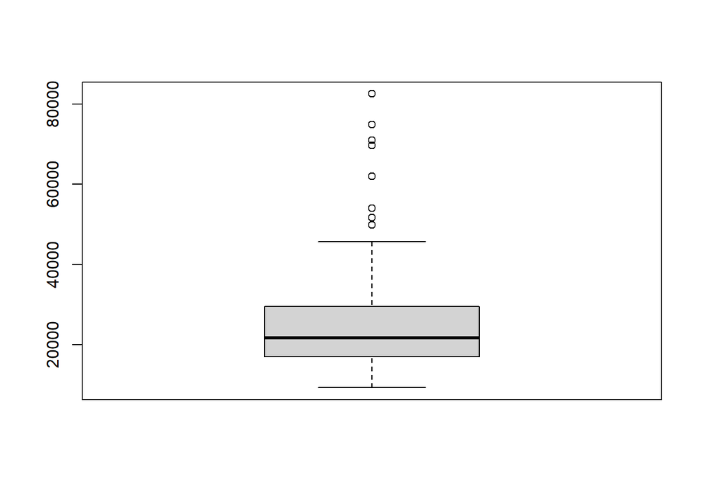

```r
boxplot(carCompleto$Precio);
```

**Boxplot del “Precio” de vehículos según el “Tipo_vehículo”**

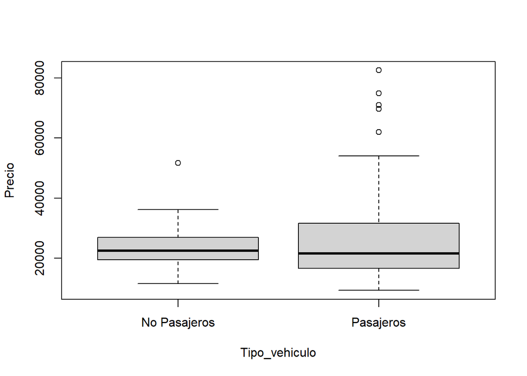

```r
boxplot(Precio~Tipo_vehiculo,data=carCompleto)
```

### 1.5.1 *Análisis del boxplot del Precio de vehículos*

- El precio mínimo y máximo de los vehículos corresponden a la categoría “Pasajeros”
- La variabilidad del 50% de los datos en la categoría de “Pasajeros” es mayor que en la de “No pasajeros” porque la longitud de la caja es mayor
- La categoría “Pasajeros” es el que tiene mayor rango de precios.
- En la categoría “Pasajeros”, la parte superior de las cajas es mayor que la inferior; ello quiere decir que los precios comprendidas entre el 50% y el 75% de los vahiculos de tipo “Pasajeros” está más dispersos que entre el 25% y el 50%.
- El bigote de abajo (Xmin, Q1) es más corto que el de arriba; por ello el 25% de los precios de los vehículos están mas concentrados que el 25% de los mayores (Q3, Xmax).
- Se muestra que la mediana en las categorías de coches es muy parecida, y no se encuentran en el centro de la caja sino mas bien cerca del primer cuartil (Q1), por lo tanto es una distribución asimetrica positiva, y en este caso la media es mayor que la mediana.
- Al observar los valores atípicos, la mayor cantidad de outliers están en la categoría pasajeros y por encima del límite superior mientras que la categoría “No pasajeros” solo tiene 1 del total de valores atípicos.

### 1.5.2 **Diagrama de Barras**

Porcentaje de vehículos según el grupo al que pertenecen

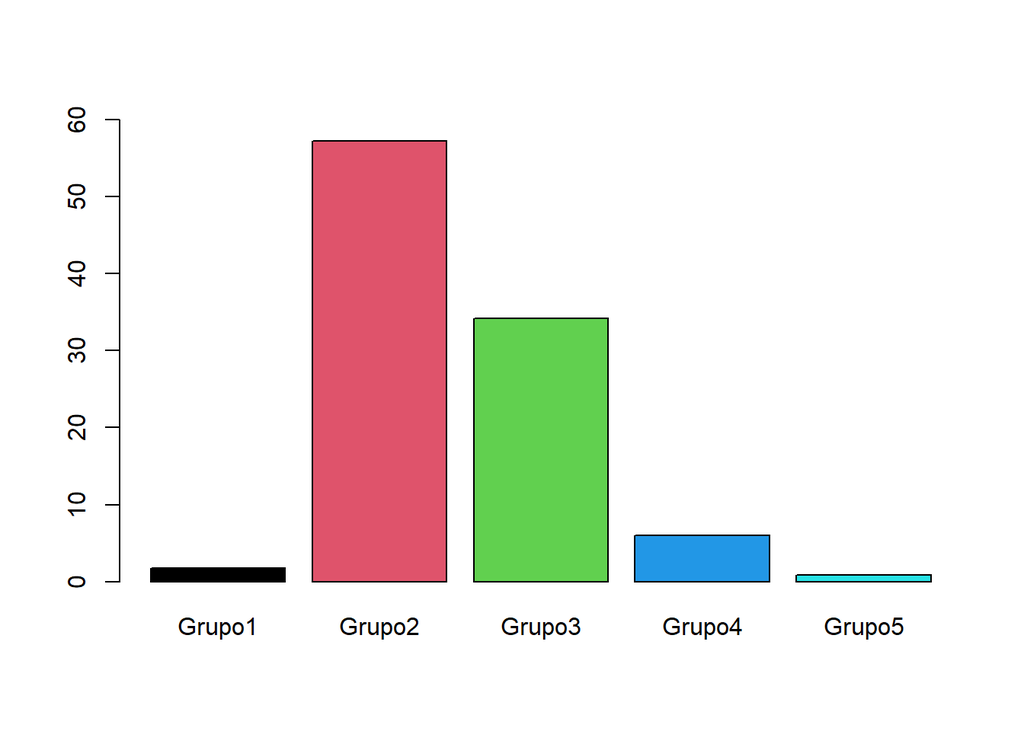

```r
barplot(table(carCompleto$Grupo)/dim(carCompleto)[1]*100, ylim = c(0, 60), col=palette("Pastel 2"));
```

### 1.5.3 **Análisis del diagrama de barras de los Grupos**

Se observan los distintos porcentajes de vehículos clasificados por Grupo:

Los vehículos se clasifican por grupos según se puntuación. Como observamos, más de la mitad de los vehículos se clasifican en el Grupo 2 teniendo una puntuación entre 40 y 79.

## 1.6 **Eliminación de Outliers**

```r
outliers <- boxplot.stats(carCompleto$Precio)$out ##Busca los valores de los outliers de la variable precio
index_outliers <- which(carCompleto$Precio %in% outliers)   #
carCompletoNet <- carCompleto[-index_outliers,]
```

**Comparación de Boxplot con outliers y sin outliers**

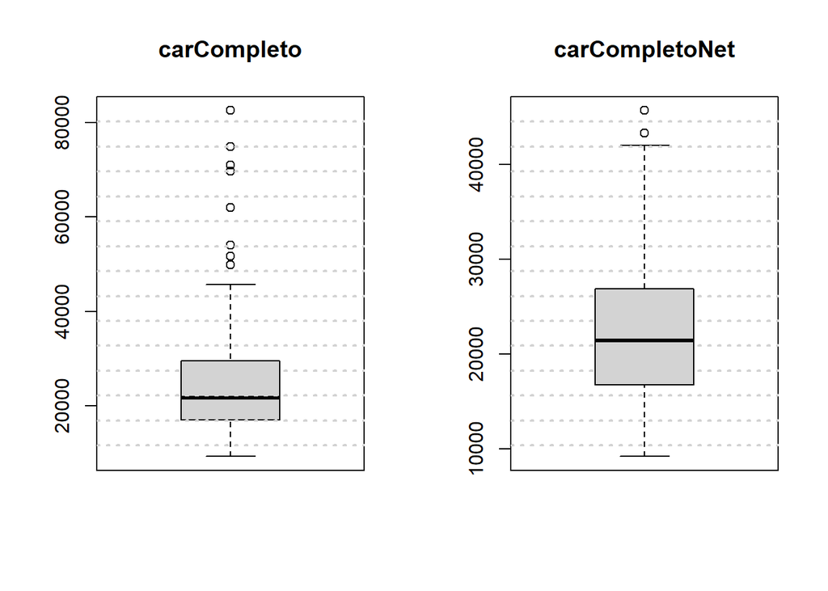

```r
par(mfrow=c(1,2));
boxplot(carCompleto$Precio, main = "carCompleto");
grid(NA,15, lwd = 2);
boxplot(carCompletoNet$Precio, main = "carCompletoNet");
grid(NA,15, lwd = 2);
```

**Calculo de la media de los data frames**

La media del Precio del data frame **carCompleto** es:

```r
mean(carCompleto$Precio)
```

```
## [1] 25969.47
```

La media del Precio del data frame **carCompletoNet** es:

```r
mean(carCompletoNet$Precio)
```

```
## [1] 22710.93
```

### 1.6.1 **Interpretación de los resultados**

**Importancia de eliminar los outliers**

En el proceso de preparación de la base de datos, se realiza la detección, corrección o eliminación de datos erroneos o inconsistentes como los valores que se encuentren fuera del rango. Sin embargo se deben analizar estos datos para saber su causa.

Los valores atipicos o outliers, pueden indicar que los datos pertenecen a una población distinta del resto de muestras. En particular, se debe analizar si existe algún patrón no aleatorio que pueda sesgar los resultados obtenidos debido a la pérdida de representatividad de la muestra analizada.

Tambien, es vital eliminar los outliers porque al considerarlos nos podrían distorsionar la media y además pueden ocasionar errores al predecir casos futuros a partir de casos conocidos.

## 1.7 **Preparación de datos para la minería de datos**

Se genera un nuevo data frame “carfinal” con las columas especificadas

```r
carfinal <- carCompleto[,1:17]
```

Se comprueba la exitencia de NA’s

```r
any(is.na(carfinal))
```

```
## [1] FALSE
```

Se muestrean un conjunto de datos de entrenamiento “train” (70).

```r
smp_size <- floor(0.7 * nrow(carfinal))
train_ind <- sample(seq_len(nrow(carfinal)), size = smp_size)
trainDataset = carfinal[train_ind,];
testDataset = carfinal[-train_ind,];
```

Se escriben los conjuntos de train en un fichero csv

```r
write.csv(trainDataset, file = "Train.csv")
```

Se escriben los conjuntos de test en un fichero csv

```r
write.csv(testDataset, file = "Test.csv")
```